# How to interpret the HTML report generated by `cellCellReport` function

Koki Tsuyuzaki, Manabu Ishii and Itoshi Nikaido

Laboratory for Bioinformatics Research, RIKEN Center for Biosystems Dynamics Reseach

k.t.the-answer@hotmail.co.jp

19 June 2019

#### Package

scTensor 1.1.0

# 1 Introduction

Here, we explain the way to interpret of HTML report generated by `cellCellReport`. If `cellCellDecomp` is properly finished, we can perform `cellCellReport` function to output the HTML report. The result can be confirmed by typing `example(cellCellReport)`. The report will be generated in the temporary directory (it costs 5 to 10 minutes).

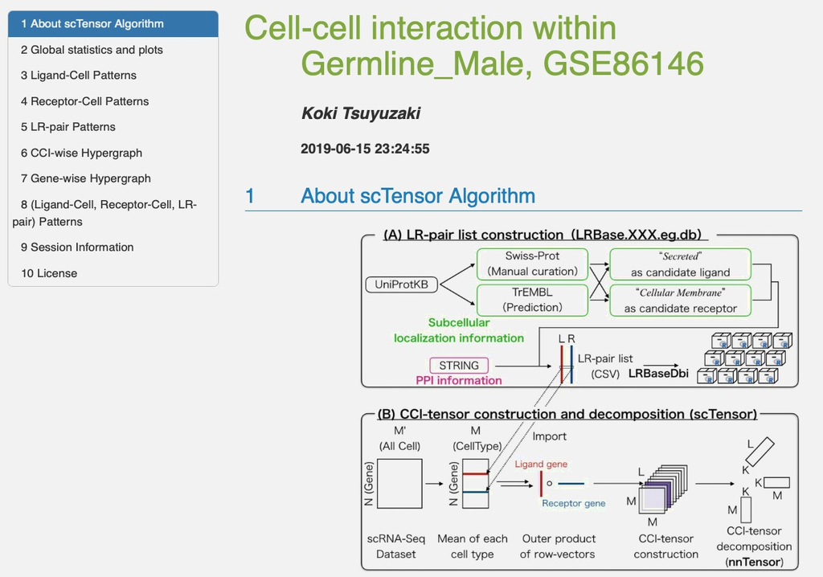

Figure1 : HTML report of `cellCellReport`

# 2 Interpretation of “1. About scTensor Algorithm”

The 1st item describes the overview of *scTensor* and other CCI-related packages.

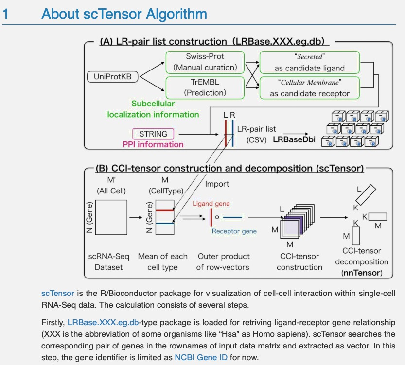

Figure2: 1. About scTensor Algorithm

# 3 Interpretation of “2. Global statistics and plots”

The 2nd item describes all the R objects saved in **reanalysis.RData**, which contains the result of *scTensor*. This file is saved in the output directory (**out.dir**) specified in `cellCellReport`, and the user also can re-analyze the result of *scTensor*.

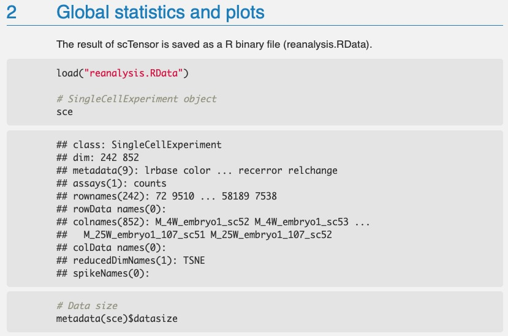

Figure3: 2. Global statistics and plots

Using *plotly* package, `cellCellReport` generates some interactive plots. For example, in item 2.1, the number of cells in each cell type can be confirmed when the cursor moved on the box.

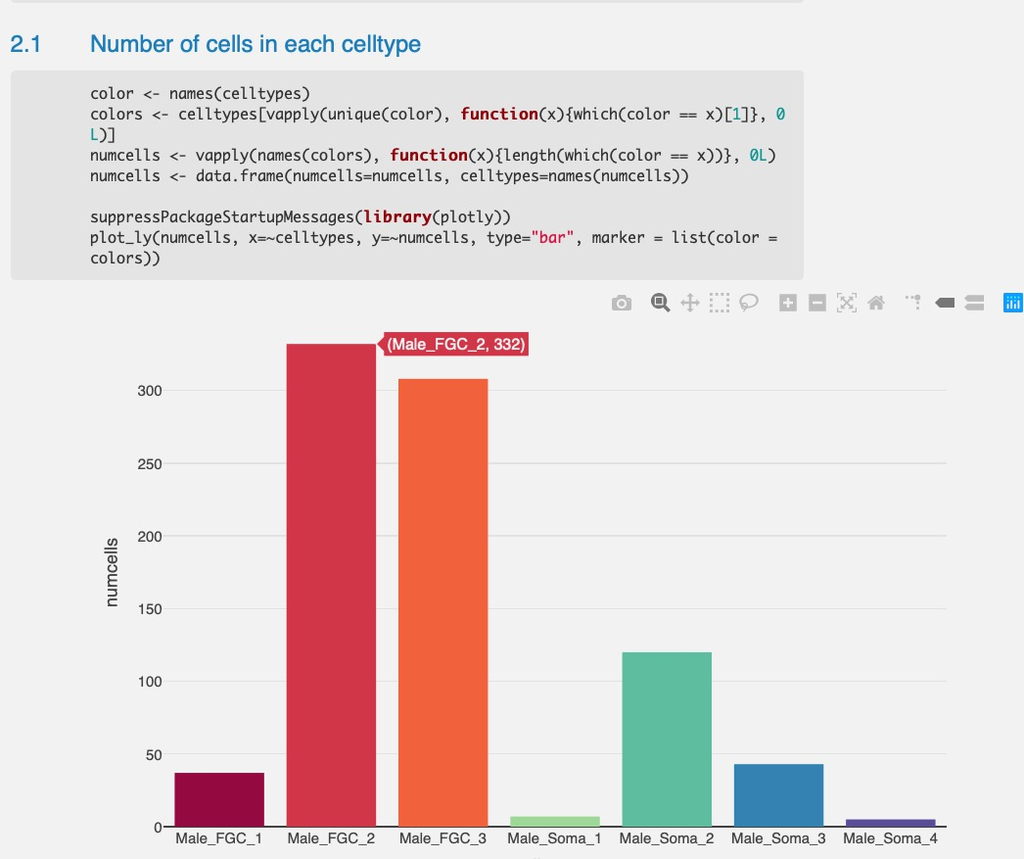

Figure4: 2.1 Number of cells in each celltype

In item 2.2, the number of expressed genes in each cell type (Non-zero genes) can be confirmed when the cursor moved on the box.

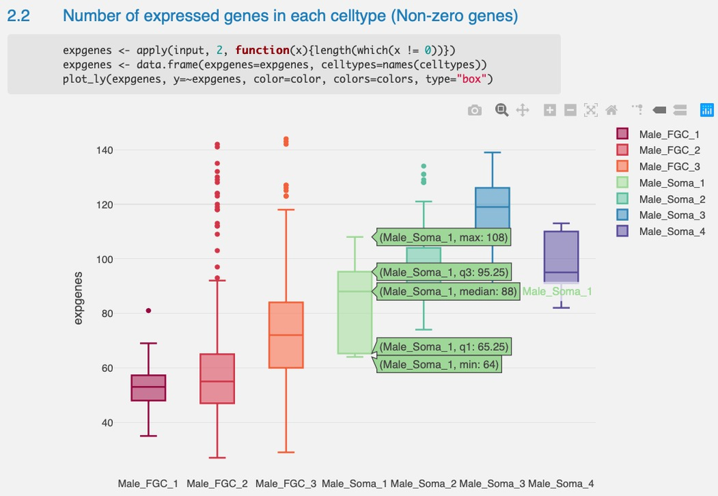

In item 2.3, two-dimensional plot user specified can be confirmed.

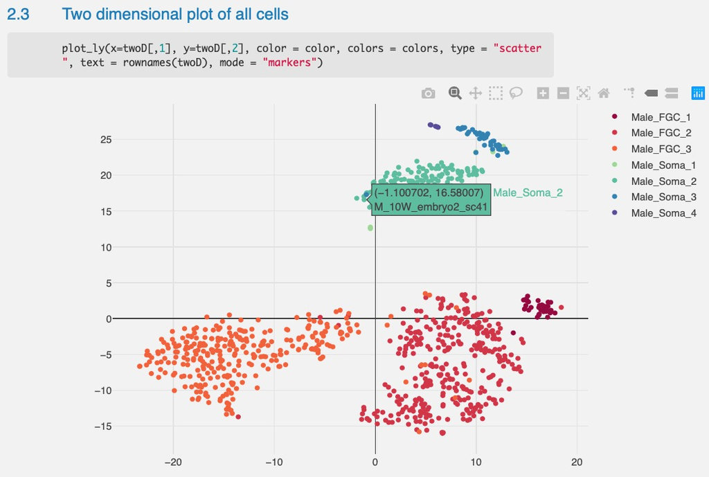

In item 2.4, distribution of core tensor values and the value of each (Ligand-Cell-type, Receptor-Cell-type, LR-pair) pattern can be confirmed.

The red bars mean that these values are selected by the threshold (**thr** parameters) in `cellCellReport`.

Note that the thr can be specified from 0 to 100, the large thr value will generate too many HTML files (cf. 8. (Ligand-Cell, Receptor-Cell, LR-pair) Patterns) and takes a long time.

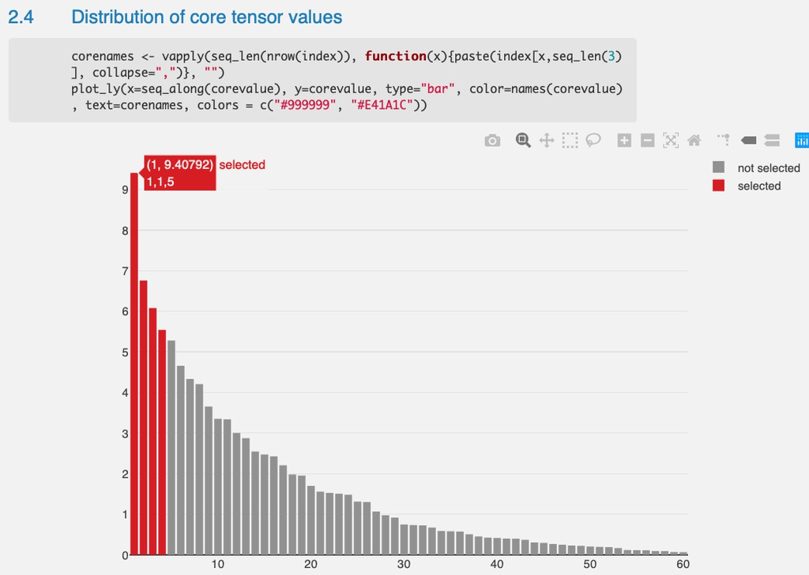

Figure7 : 2.4 Distribution of core tensor values

The 3-order CCI-tensor consisting of Cell_L $\times$ Cell_R $\times$ LR-pair (LR) are decomposed by *nnTensor*, in which the tensor is iteratively matricised to mode-1 (Ligand-Cell direction), mode-2 (Receptor-Cell direction), and mode-3 direction (LR-pair direction).

In each direction, NMF is performed and the strength of each directional patterns are summarized in the bar plots.

For example, in item 2.5, distribution of mode-1 matricised tensor can be confirmed.

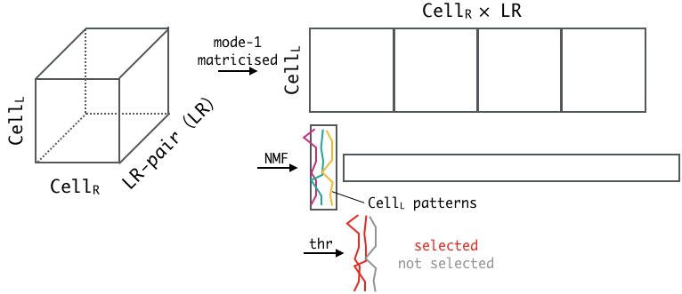

Figure8: 2.5 Distribution of mode-1 matricised tensor (Ligand-Cell Direction) (1/2)

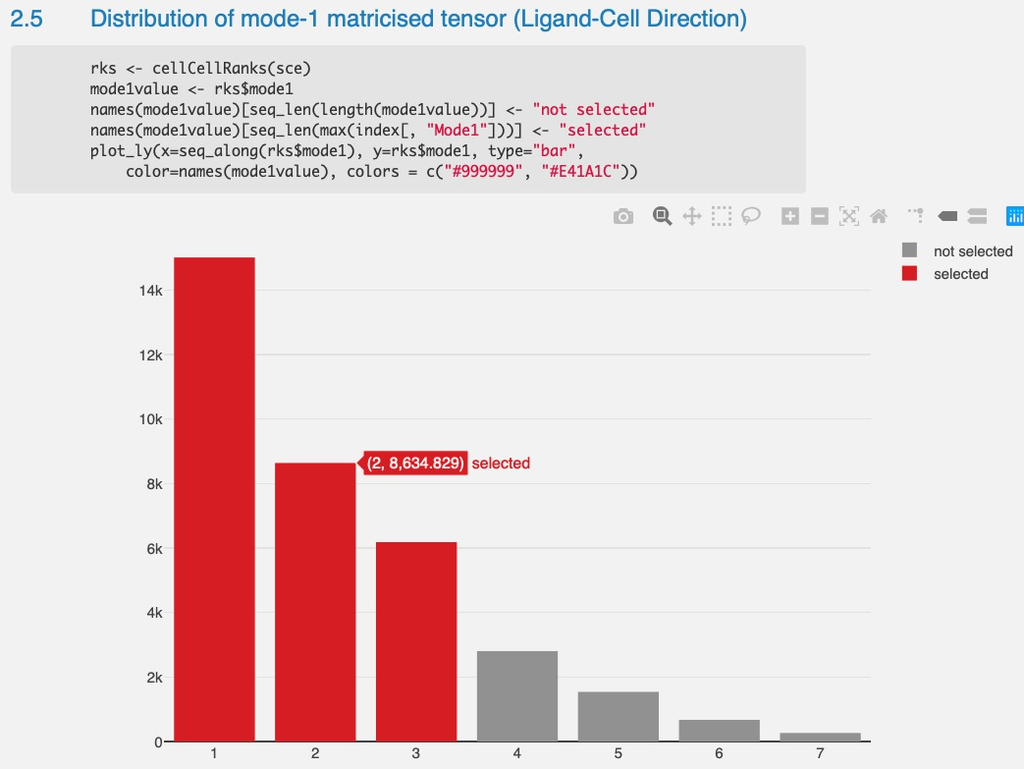

Figure9: 2.5 Distribution of mode-1 matricised tensor (Ligand-Cell Direction) (2/2)

Likewise, in item 2.6, distribution of mode-2 matricised tensor can be confirmed,

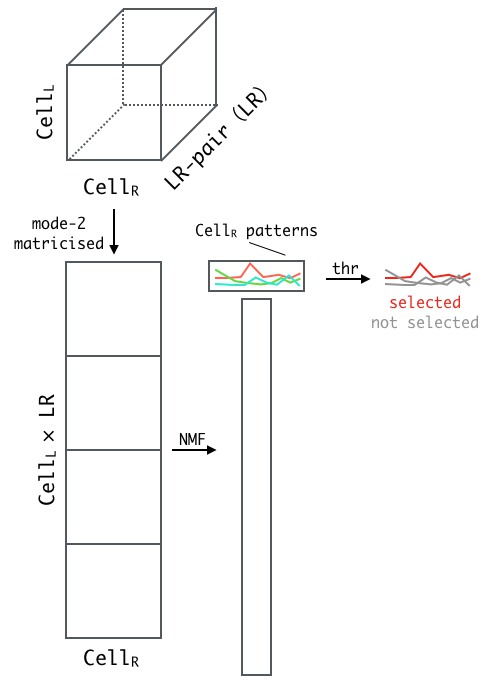

Figure10 : 2.6 Distribution of mode-2 matricised tensor (Receptor-Cell Direction) (1/2)

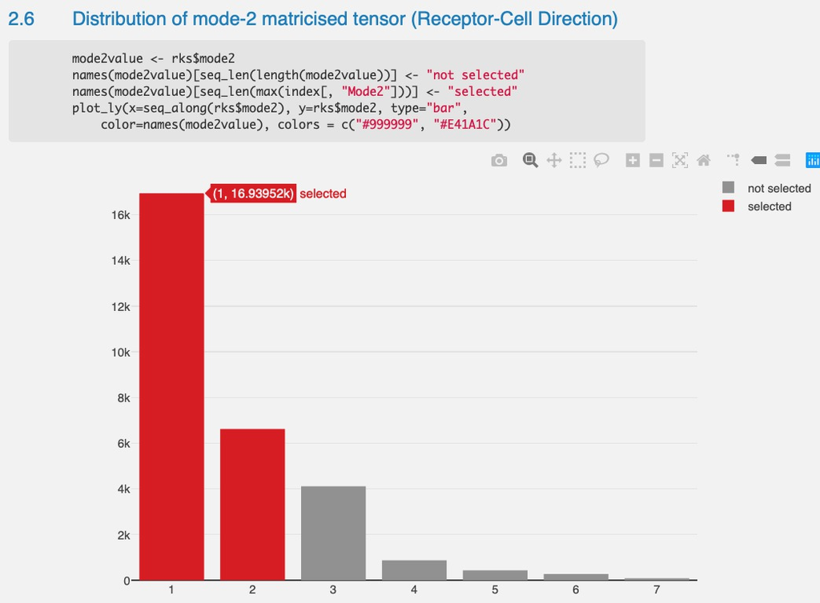

Figure11 : 2.6 Distribution of mode-2 matricised tensor (Receptor-Cell Direction) (2/2)

and in item 2.7, distribution of mode-3 matricised tensor can be confirmed,

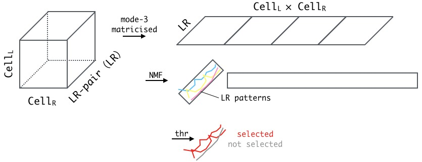

Figure12 : 2.7 Distribution of mode-3 matricised tensor (LR-pair Direction) (1/2)

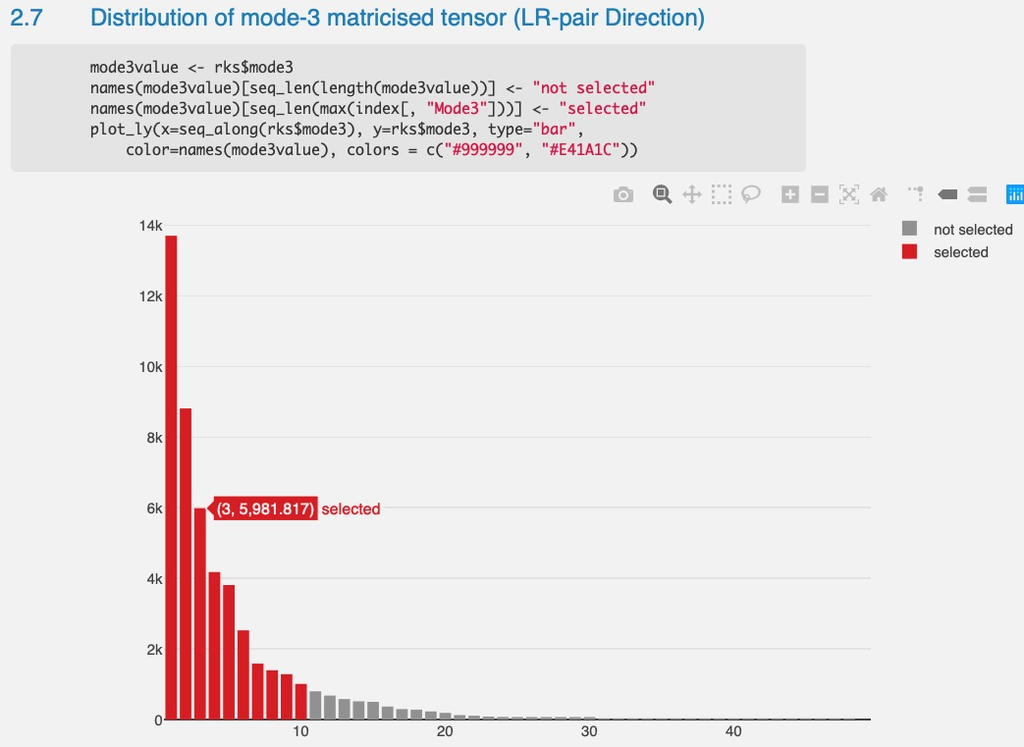

Figure13 : 2.7 Distribution of mode-3 matricised tensor (LR-pair Direction) (2/2)

# 4 Interpretation of “3. Ligand-Cell Patterns”

In the 3rd item, using heatmap of *plotly*, user can interactively confirm the detail of Ligand-Cell Patterns extracted by *nnTensor*.

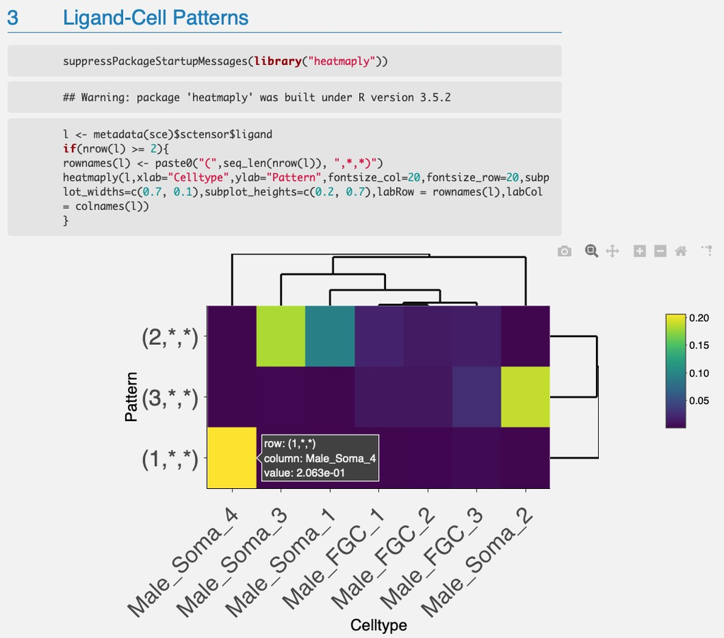

Figure14 : 3. Ligand-Cell Patterns

# 5 Interpretation of “4. Receptor-Cell Patterns”

Likewise, in the 4th item, the user can interactively confirm the detail of Receptor-Cell Patterns.

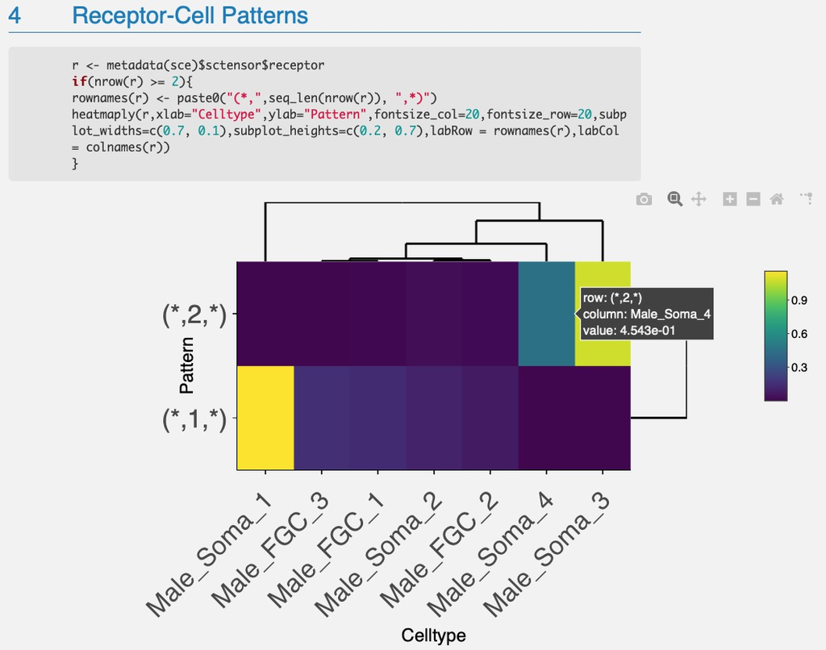

Figure15 : 4. Receptor-Cell Patterns

# 6 Interpretation of “5. LR-pair Patterns”

In the 5th item, the user can interactively confirm the detail of LR-pair Patterns.

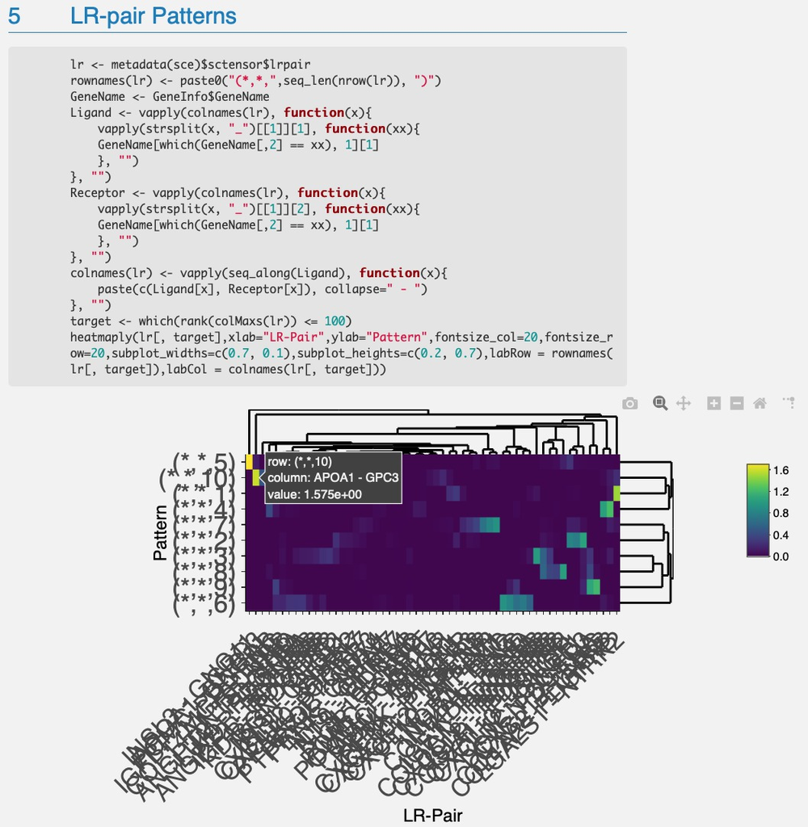

Figure16 : 5. LR-pair Patterns

Since the LR-pairs patterns are messed up because of the length of vectors, in this plot (and also in other *plotly* plots), we recommend the user to try the zoom-in view of *plotly*. In this view, the user can confirm which LR-pattern have what kind of LR-pairs.

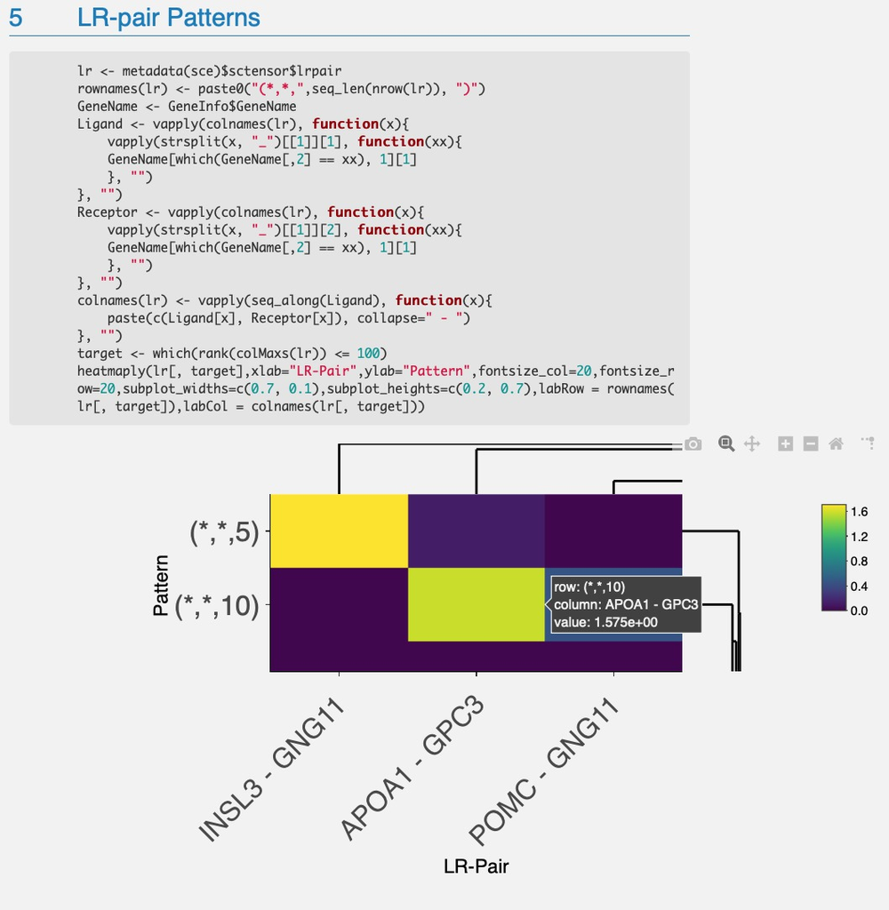

Figure17 : 5. LR-pair Patterns (Zoom in)

# 7 Interpretation of “6. CCI-wise Hypergraph”

In the 6th item describes, the strength between Ligand-Cell Patterns and Receptor-Cell Patterns (CCI-strength), by the summation of the core tensor with the mode-3 direction, a matrix consisting of the number of Ligand-Cell Patterns $\times$ the number of Receptor-Cell Patterns.

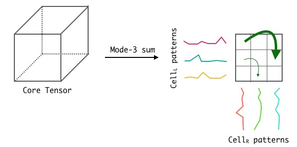

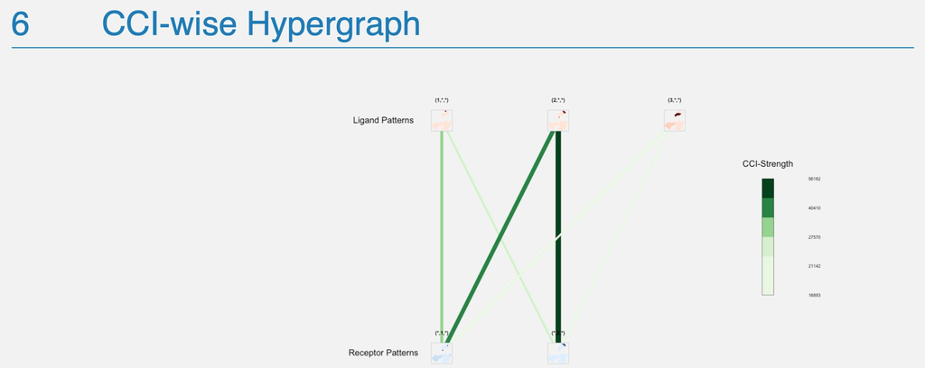

# 8 Interpretation of “7. Gene-wise Hypergraph”

In the 7th item, the relationship between LR-pairs, which coexpressed in any LR-pair pattern at least one time. Ligand genes are described as red nodes, receptor genes are described as blue nodes, and corresponding LR-pair patterns are described as the color of edges.

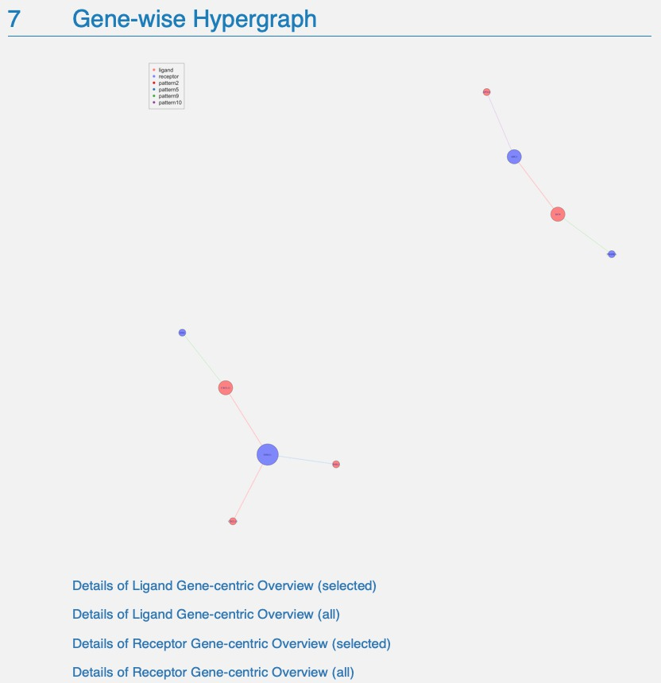

Figure20 : 7. Gene-wise Hypergraph

Under the gene-wise hypergraph, four links are embedded.

In the 1st link, the details of gene-wise hypergraph can be confirmed as a corresponding table in a ligand gene-centric manner. This page can work as reverse lookup search by “Ctrl + F”; by typing the gene name of ligand that the user is interested in, the partner receptors, which are coexpressed in some LR-pair patterns, also can be found.

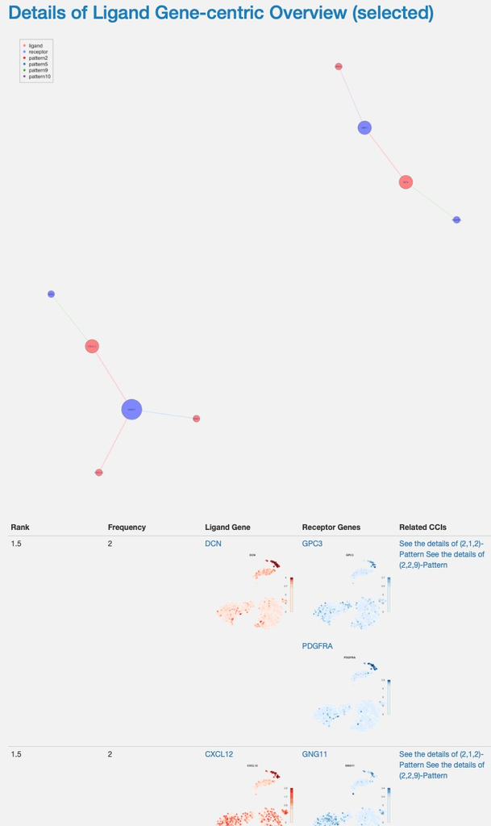

In the 2nd link, the user can find all the partner receptors, even if the partner receptors are not coexpressed in any LR-pair pattern, and if they are not included in the data matrix.

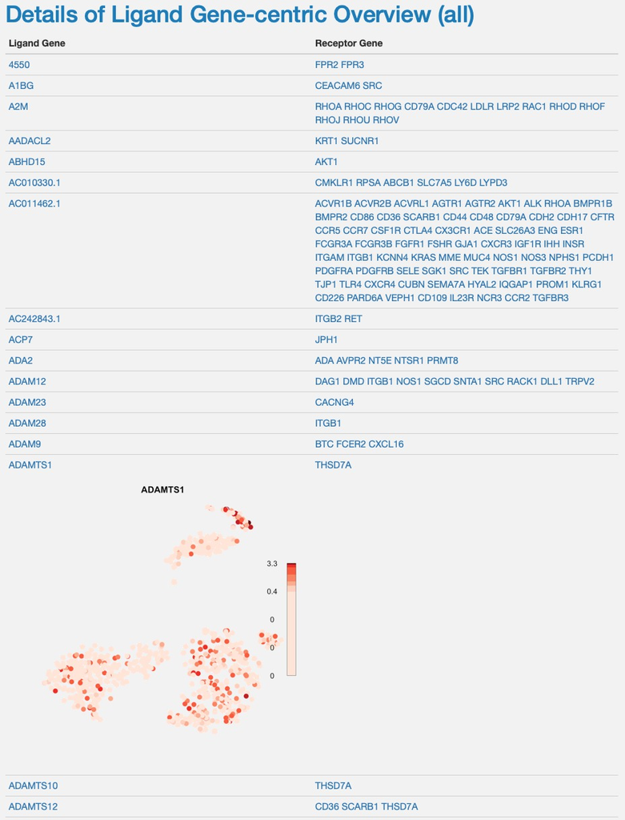

Likewise, the receptor gene-centric reverse search page is embedded in the 3rd link,

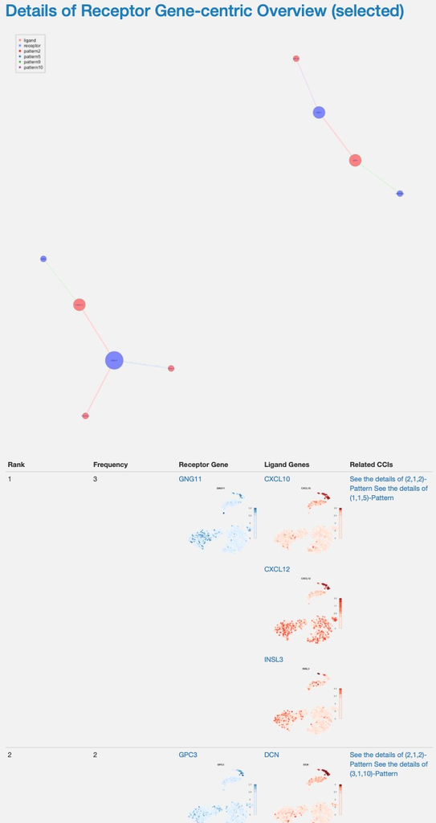

and, in the 4th link, all the partner ligand genes are included.

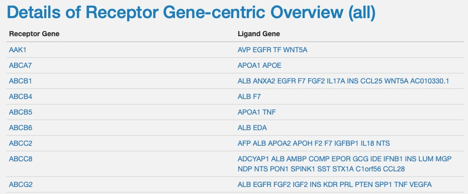

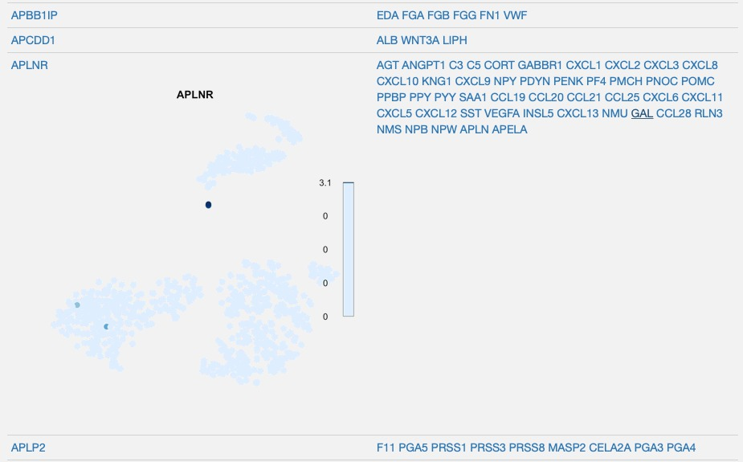

# 9 Interpretation of “8. (Ligand-Cell, Receptor-Cell, LR-pair) Patterns”

In the 8th item, the details of (Ligand-Cell, Receptor-Cell, LR-pair) Patterns are ordered by the size of core tensor, and the link of each pattern is embedded.

(Note that the number of the number of links is dependent on the **thr** parameter of `cellCellReport`.)

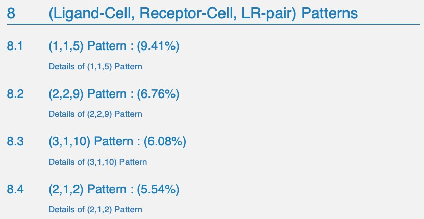

For example, the 1st link describes the details of (1,1,5) Pattern, which means the relationship of *1*st pattern of Ligand-Cell patterns, *1*st pattern of Receptor-Cell patterns, and *5*th pattern of LR-pair patterns.

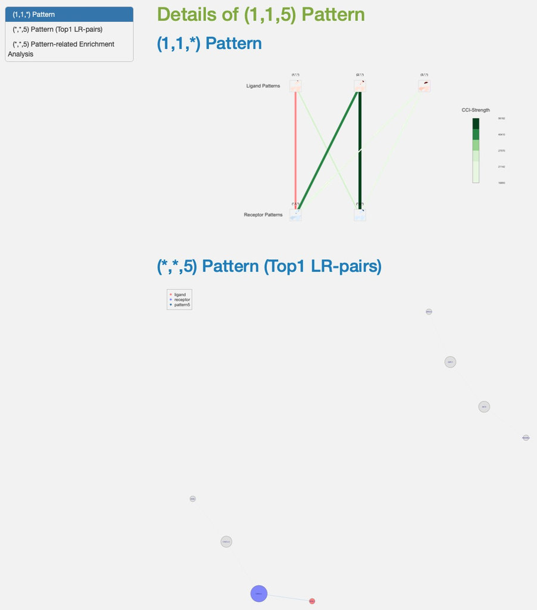

In this pattern, only one LR-pair is coexpressed (INSL3 and GNG11). The hyperlinks to many databases and PubMed are also embedded. The degree of the size of the LR-pair in the LR-pair pattern is quantified as P-value and Q-value.

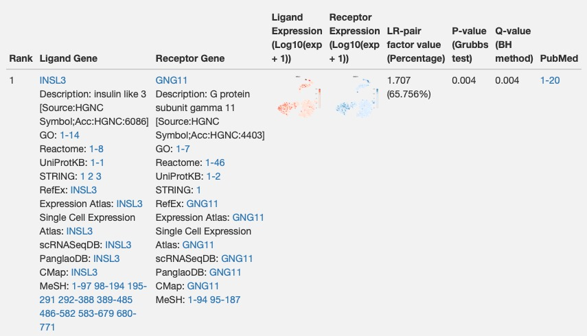

Under the LR-pair list, the results of many enrichment analysis is also embedded such as Gene Ontology (BP/MF/CC), Reactome, MeSH…etc.

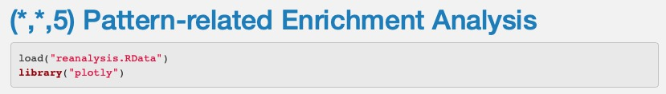

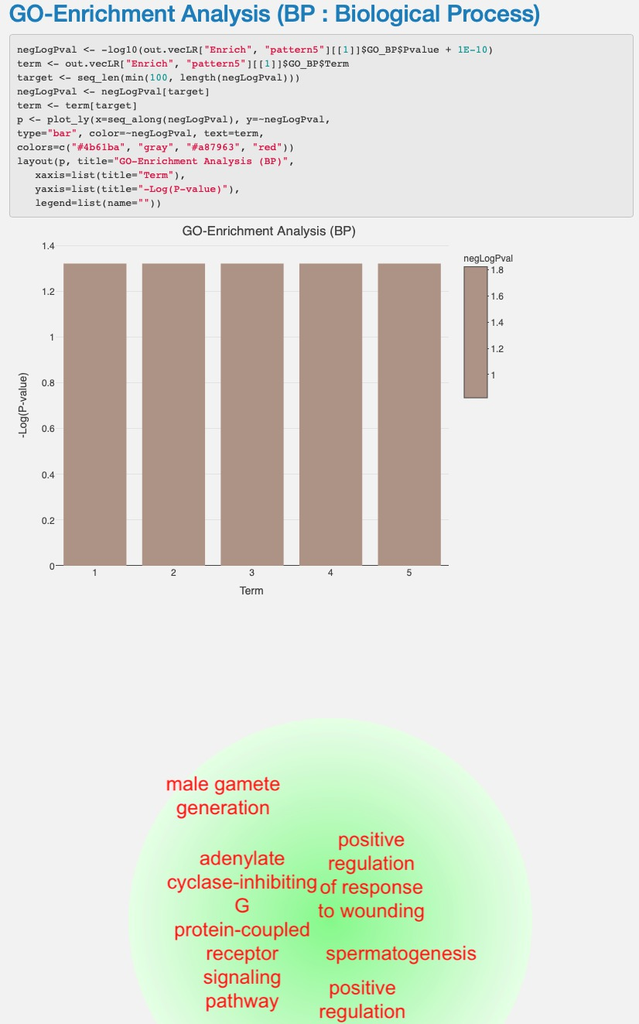

User can confirm the detail of the result of *scTensor*, and perform the biological interpretation.